# Analysis of the citizen initiatives and civic crowdfunding survey for BrusselsTogether

### Distribution of answers for independent variables broken down by age

Here below is a plot showing the mean age versus answers to the independent variables questions, broken down by the independent variables questions.

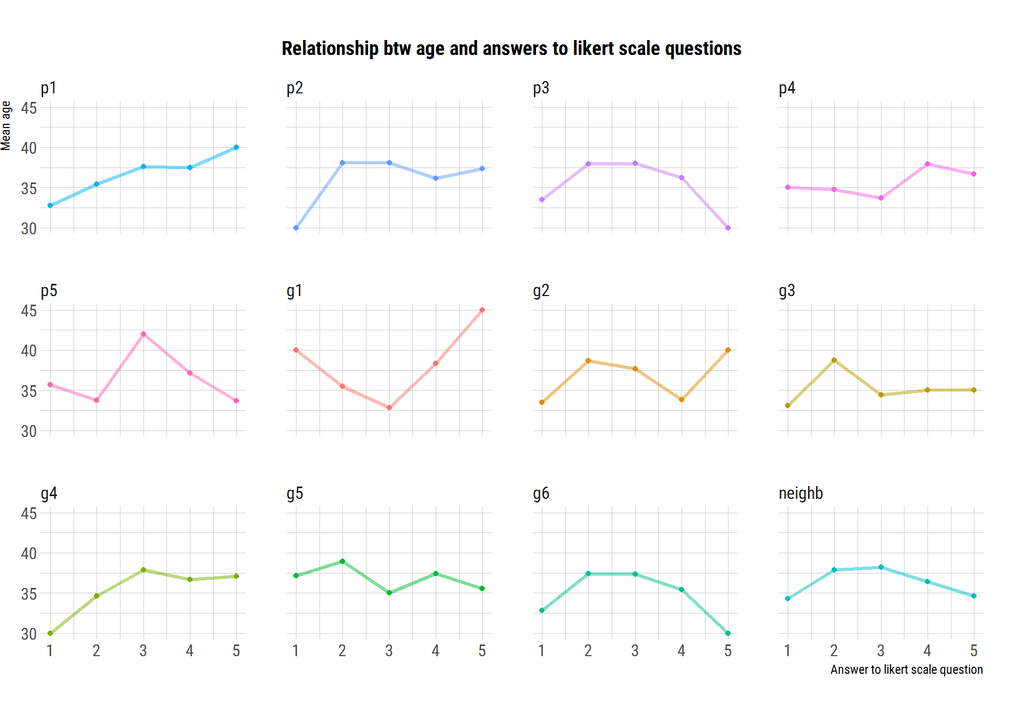

```r
survey_df_c <- survey_df_c %>%
  mutate(age_num = ifelse(age == "14_and_below", 12,
                          ifelse(age == "14_17", 16,
                                 ifelse(age == "18_24", 20,
                                        ifelse(age == "25_34", 30,
                                               ifelse(age == "35_44", 40,
                                                      ifelse(age == "45_54", 50,
                                                             ifelse(age == "55_64", 60,
                                                                    ifelse(age == "65_74", 70, 80)))))))))

tidy_survey_df_c <- survey_df_c %>%
  select(age_num, p1:g6, neighb) %>%
  data.matrix() %>%
  as_data_frame() %>%
  gather(key, value, -age_num)

tidy_survey_df_c %>%
  group_by(key, value) %>%
  summarize(age_num = mean(age_num, na.rm = TRUE)) %>%
  ggplot(aes(value, age_num, color = key)) +
  geom_line(size = 1.2, show.legend = FALSE, alpha = 0.5) +
  geom_point() +
  labs(title = "Relationship btw age and answers to likert scale questions",
       x = "Answer to likert scale question", y = "Mean age") +
facet_wrap(~factor(key, ordered = T,
                   levels = c("p1", "p2", "p3", "p4", "p5", "g1", "g2",
                              "g3", "g4", "g5", "g6", "neighb")), nrow = 3) +
  theme_ipsum_rc() +
  theme(plot.title = element_text(size = 14, hjust = 0.5)) +
  theme(axis.text.y = element_text(hjust = 0)) +
  theme(legend.position = "none") +
  theme(plot.margin = unit(c(1,1,1,0), "cm"))
```

For this plot, the age group is coded as an integer value as shown in the following table (see the column `age_num`). This table also shows the count for each level (under the column `n`).

```r
options(scipen = 999, digits = 3)

survey_df_c %>%
  count(age, age_num) %>%
  kable() %>%
  kable_styling(bootstrap_options = c("striped", "hover"),
                full_width = F, position = "left", font_size = 14)
```

| age | age_num | n |
| --- | --- | --- |
| 18_24 | 20 | 15 |
| 25_34 | 30 | 82 |
| 35_44 | 40 | 14 |
| 45_54 | 50 | 26 |
| 55_64 | 60 | 12 |
| 65_74 | 70 | 2 |
| 75_plus | 80 | 1 |

Similar to the previous plot, we can observe from this plot that there is a possible positive relationship between age and the extent to which the participant agreed with the statement: **Personally funding a citizen’s initiative is enough to satisfy my desire to engage in this project**, although this should be confirmed/quantified with the statistical modeling that we will perform in the next chapter.

# Logistic Regression modeling

### Introduction

In this chapter, we are going to fit a series of multiple binary logistic regression models (which are the most basic model used to predict a categorical response, such as our two dependent variables ‘interest’ and ‘past investment’). This is useful because these models will allow us to see which predictors (in our case the independent variables and control variables) are associated with the likelihood of people to be interested in supporting citizens initiatives.

This kind of models can only predict a target variable which has two classes, thus the term binary. However, our dependent variables have more than two classes (for example, there are five classes for the ‘interest’ variable, from ‘Not interested’ up to ‘Ready to fund’). Therefore, we will fit several models one after the other after having split our dependent variable classes into two groups in several ways. This is called the ‘one versus rest’ approach. There are of course more complex models that can handle more than two classes in the target variable, but we will keep things simple here.

Note that designing a survey with ordinal categorical variables (i.e. categorical variables which have a natural order) such as questions with choices on a 5-point Likert scale or age or education makes it easier to interpret the results of the models, as we will see next.

### Logistic regression with Interest as the target variable

#### Model 1

In this section, we will fit a model with ‘Interest’ (in supporting citizens initiatives) as the target variable and all of the independent variables, as well as the control variables, as the explanatory variables.

In this model, we will split the Interest variable into the two following groups:

- Class 0: `Not_interested`;
- Class 1: The rest of the possible classes combined (`Could_be_interested_Vol`, `Could_be_interested_Fund`, `Is_ready_Vol` and `Is_ready_Fund`).

Also, we filter out observations with gender other than `Female` and `Male`. Then, `Female` are represented by the integer value 1 and Male are represented by the integer value 2 (there is no particular reason for this, we could do it the other way around).

Answers to Likert scale questions range from 1 (`Strongly_disagree`) to 5 (`Strongly agree`).

Answers to the question about the age of the respondent range from 1 (`Under_14`) to 9 (`75_plus`).

Answers to the education question range from 1 (`Primary_or_None`) to 6 (`PhD`).

Finally, answers to the location and language questions have three levels:

- `Brussels` = 1, `Flanders` = 2, `Wallonia` = 3;
- `English` = 1, `Dutch` = 2, `French` = 3.

Thus, the first few rows of the input to the model look like this:

```r
survey_df_c_mat <- survey_df_c %>%
  filter(gender %in% c("Female", "Male")) %>%
  mutate(interest_binary = ifelse(interest == "Not_interested",
                                  0,
                                  1)) %>%
  select(interest_binary, language, p1:edu, -invest) %>%
  data.matrix() %>%
  as_data_frame()

survey_df_c_mat %>%
  head() %>%
  kable() %>%
  kable_styling(bootstrap_options = c("striped", "hover"),
                full_width = T, font_size = 14)
```

| interest_binary | language | p1 | p2 | p3 | p4 | p5 | g1 | g2 | g3 | g4 | g5 | g6 | neighb | loc | gender | age | edu |
| --- | --- | --- | --- | --- | --- | --- | --- | --- | --- | --- | --- | --- | --- | --- | --- | --- | --- |
| 1 | 3 | 2 | 2 | 2 | 4 | 4 | 2 | 3 | 2 | 4 | 2 | 2 | 4 | 1 | 1 | 4 | 5 |
| 1 | 1 | 3 | 3 | 2 | 2 | 4 | 1 | 4 | 2 | 4 | 4 | 4 | 4 | 1 | 2 | 6 | 6 |
| 1 | 3 | 2 | 4 | 2 | 3 | 5 | 4 | 4 | 2 | 5 | 3 | 3 | 5 | 1 | 2 | 5 | 4 |
| 1 | 3 | 3 | 3 | 3 | 3 | 4 | 2 | 3 | 3 | 4 | 4 | 4 | 3 | 2 | 2 | 8 | 3 |
| 1 | 3 | 3 | 3 | 2 | 4 | 1 | 4 | 3 | 2 | 3 | 3 | 4 | 4 | 1 | 2 | 6 | 5 |
| 1 | 2 | 4 | 5 | 4 | 4 | 4 | 2 | 5 | 2 | 4 | 4 | 2 | 4 | 1 | 1 | 4 | 5 |

Let us now examine the output of the model:

```r
glm1 <- glm(interest_binary ~ .,  family = "binomial",
                  data = survey_df_c_mat)

summary(glm1)
```

```
##
## Call:
## glm(formula = interest_binary ~ ., family = "binomial", data = survey_df_c_mat)
##
## Deviance Residuals:
##         Min           1Q       Median           3Q          Max
## -0.00013589   0.00000002   0.00000002   0.00000002   0.00011225
##
## Coefficients:
##              Estimate Std. Error z value Pr(>|z|)
## (Intercept)   -712.10  260294.49    0.00        1
## language       104.17   25318.23    0.00        1
## p1              -2.82    8753.77    0.00        1
## p2              -6.25   13890.32    0.00        1
## p3             -34.86   21457.88    0.00        1
## p4              34.80   17255.02    0.00        1
## p5             -23.91   12686.23    0.00        1
## g1              11.38   18054.07    0.00        1
## g2              35.47   16975.20    0.00        1
## g3              88.56   23372.16    0.00        1
## g4              87.05   24097.56    0.00        1
## g5              28.90   10846.46    0.00        1
## g6             -32.60   14709.20    0.00        1
## neighb         103.56   20100.27    0.01        1
## loc            -28.77   15039.57    0.00        1
## gender        -134.84   59506.52    0.00        1
## age            -38.48   11978.54    0.00        1
## edu             46.11    9663.82    0.00        1
##
## (Dispersion parameter for binomial family taken to be 1)
##
##     Null deviance: 56.669538353445  on 150  degrees of freedom
## Residual deviance:  0.000000084893  on 133  degrees of freedom
## AIC: 36
##
## Number of Fisher Scoring iterations: 25
```

This is a lot of output, but we are going to focus on the Coefficients table in the middle.

In order to be able to interpret anything meaningful, we first have to look at the p-values represented in the last column of the Ceofficients table (`Pr(>|z|)`). The p-value is used to test for statistical significance. We won’t go into the theory of inference for regression, but simply put, low p-values (below 0.05) generally mean that we can rule out that the effect of the coefficient is due to chance. In other words, we are looking for coefficients for which the p-value is below 0.05.

In the present case, all p-values are about 1, so this model is useless. In fact, the model did not converge. This is probably due to the high imbalance in the target variable. Indeed, as already mentionned, the class `Not_interested` represents only 5% of the sample or 7 out of 152 observations.

Therefore, we cannot infer anything regarding factors that could be associated with the likelihood of people not to be interested in citizens initiatives as opposed to being somewhat interested (‘Could be interested’) or definetly interested (‘Is ready’).

#### Model 2

In this second model, we are filtering out the observations where people are not interested in citizens initiatives, therefore we are now focusing on a subset of the data. Then we split the observations into the following two groups, related to the `interest` variable:

- Class 0: `Could_be_interested_Vol` and `Could_be_interested_Fund`;
- Class 1: `Is_ready_Vol` and `Is_ready_Fund`.

The rest of the model is similar to the model 1.

```r
survey_df_c_mat <- survey_df_c %>%
  filter(gender %in% c("Female", "Male")) %>%
  filter(interest != "Not_interested") %>%
  mutate(interest_binary = ifelse(interest %in% c("Is_ready_Vol",
                                                  "Is_ready_Fund"),
                                  1,
                                  0)) %>%
  select(interest_binary, language, p1:edu, -invest) %>%
  data.matrix() %>%
  as_data_frame()

glm2 <- glm(interest_binary ~ .,  family = "binomial",
                  data = survey_df_c_mat)

summary(glm2)
```

```
##
## Call:
## glm(formula = interest_binary ~ ., family = "binomial", data = survey_df_c_mat)
##
## Deviance Residuals:
##    Min      1Q  Median      3Q     Max
## -1.708  -0.860  -0.505   0.952   2.208
##
## Coefficients:
##             Estimate Std. Error z value Pr(>|z|)
## (Intercept)  -2.0048     3.1302   -0.64   0.5219
## language     -0.1270     0.3240   -0.39   0.6950
## p1           -0.3370     0.2209   -1.53   0.1272
## p2            0.7007     0.2650    2.64   0.0082 **
## p3            0.1394     0.2150    0.65   0.5166
## p4           -0.6186     0.2582   -2.40   0.0166 *
## p5           -0.2407     0.2119   -1.14   0.2560
## g1            0.2197     0.2415    0.91   0.3629
## g2            0.1062     0.2018    0.53   0.5985
## g3            0.3367     0.2103    1.60   0.1093
## g4           -0.5030     0.2553   -1.97   0.0488 *
## g5           -0.1043     0.2613   -0.40   0.6898
## g6           -0.0468     0.3032   -0.15   0.8774
## neighb        0.4887     0.2442    2.00   0.0453 *
## loc          -0.0153     0.2885   -0.05   0.9577
## gender        0.1171     0.4288    0.27   0.7847
## age           0.3703     0.1818    2.04   0.0417 *
## edu           0.0259     0.2613    0.10   0.9211
## ---
## Signif. codes:  0 '***' 0.001 '**' 0.01 '*' 0.05 '.' 0.1 ' ' 1
##
## (Dispersion parameter for binomial family taken to be 1)
##
##     Null deviance: 187.20  on 143  degrees of freedom
## Residual deviance: 151.49  on 126  degrees of freedom
## AIC: 187.5
##
## Number of Fisher Scoring iterations: 5
```

Now we have several variables for which the p-value of the coefficient is less than 0.05. Let’s extract them into the following table, which is ordered by `estimate` in descending order:

```r
options(scipen = 999, digits = 3)

glm2 %>%
  tidy() %>%
  filter(p.value < 0.05) %>%
  arrange(desc(estimate)) %>%
  kable() %>%
  kable_styling(bootstrap_options = c("striped", "hover"),
                full_width = F, position = "left", font_size = 14)
```

| term | estimate | std.error | statistic | p.value |
| --- | --- | --- | --- | --- |
| p2 | 0.701 | 0.265 | 2.64 | 0.008 |
| neighb | 0.489 | 0.244 | 2.00 | 0.045 |
| age | 0.370 | 0.182 | 2.04 | 0.042 |
| g4 | -0.503 | 0.255 | -1.97 | 0.049 |
| p4 | -0.619 | 0.258 | -2.40 | 0.017 |

We can interpret this table as follows:

1. Since the effect size (i.e. the estimate of the coefficient) associated with the variable `p2` is above zero, then people agreeing with the statement: **I would like to participate in debates on local public issues** are more likely to be ‘ready’ to fund or volunteer (they are more likely to have answered ‘I am ready to…’ rather than ‘I could be interested to…’), *after controlling for the other variables in the model*.

Let’s have a look at a plot similar to what we did in the Exploratory Data Analysis (EDA), but without the category `Not_interested`:

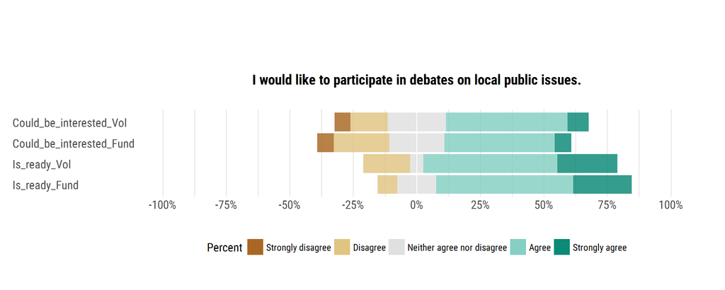

```r
t_p2 <- prop.table(table(survey_df_c$interest[survey_df_c$interest != "Not_interested"], survey_df_c$p2[survey_df_c$interest != "Not_interested"]), 1)
p2_title <- "\n\n\nI would like to participate in debates on local public issues.\n"

lik_plot(t_p2, my_df_names, mylevels, factor_levels, p2_title)
```

This confirms visually the positive relationship identified in point 1.

2. Similarly, since the effect size associated with the variable `neighb` is positive, then people agreeing with the statement: **My interest in contributing to the future of my neighborhood has increased in the past several years** are more likely to be ‘ready’ to fund or volunteer, *after controlling for the other variables in the model*.

Let’s have a look at a plot similar to what we did in the EDA, but without the category `Not_interested`:

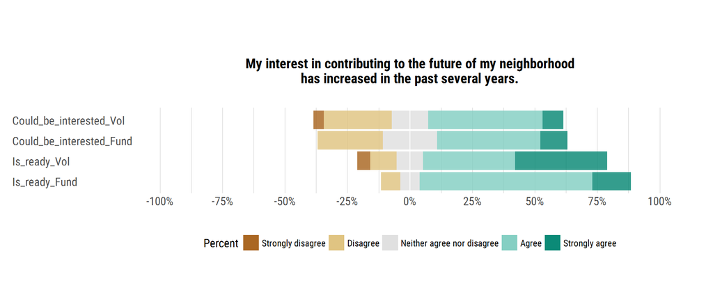

```r
t_neighb <- prop.table(table(survey_df_c$interest[survey_df_c$interest != "Not_interested"], survey_df_c$neighb[survey_df_c$interest != "Not_interested"]), 1)
neighb_title <- "\n\nMy interest in contributing to the future of my neighborhood\nhas increased in the past several years.\n"

lik_plot(t_neighb, my_df_names, mylevels, factor_levels, neighb_title)
```

This confirms visually the positive relationship identified in point 2.

3. Since the effect size associated with the variable `age` is above zero, then older people are more likely to be ‘ready’ to fund or volunteer, *after controlling for the other variables in the model*.

Let’s have a look at a bar chart representing the proportions of interest conditionned on the age group:

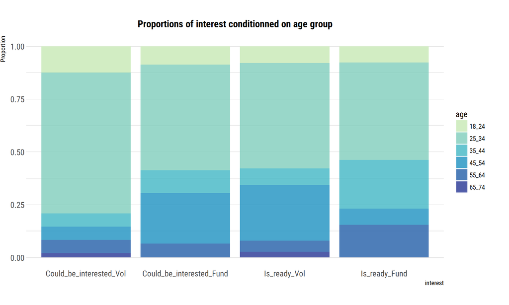

```r
my_cols <- brewer.pal(9, "YlGnBu")

survey_df_c %>%
  filter(interest != "Not_interested") %>%
  ggplot(aes(x = interest, fill = age)) +
  geom_bar(alpha = 0.8, position = "fill") +
  labs(title = "Proportions of interest conditionned on age group", y = "Proportion") +
  theme_ipsum_rc() +
  scale_fill_manual(values = my_cols[3:9]) +
  theme(panel.grid.major.x = element_blank(),
        panel.grid.minor.x = element_blank()) +
  theme(plot.title = element_text(size = 14, hjust = 0.5)) +
  theme(axis.text.y = element_text(hjust = 0)) +
  theme(plot.margin = unit(c(1,1,1,0), "cm"))
```

This plot seems to confirm the positive relationship identified in point 3.

4. Since the effect size associated with the variable `g4` is negative, then people agreeing with the statement: **Civic crowdfunding platforms could play a role of intermediary between citizen’s initiatives and the local government** are less likely to be ‘ready’ to fund or volunteer (they are more likely to have answered ‘I could be interested to…’), *after controlling for the other variables in the model*.

Let’s have a look at a plot similar to what we did in the EDA, but without the category `Not_interested`:

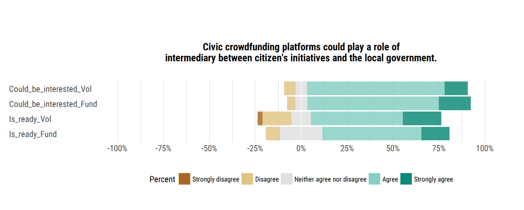

```r
t_g4 <- prop.table(table(survey_df_c$interest[survey_df_c$interest != "Not_interested"], survey_df_c$g4[survey_df_c$interest != "Not_interested"]), 1)
g4_title <- "\n\nCivic crowdfunding platforms could play a role of\nintermediary between citizen's initiatives and the local government.\n"

lik_plot(t_g4, my_df_names, mylevels, factor_levels, g4_title)
```

This confirms visually the negative relationship identified in point 4.

5. Finally, since the effect size associated with the variable `p4` is negative, then people agreeing with the statement: **I would be more inclined to contribute financially to a project on a civic crowdfunding platform if I had the possibility to express my disagreement about some aspects of the project** are less likely to be ‘ready’ to fund or volunteer (they are more likely to have answered ‘I could be interested to…’), *after controlling for the other variables in the model*.

Let’s try to confirm this visually:

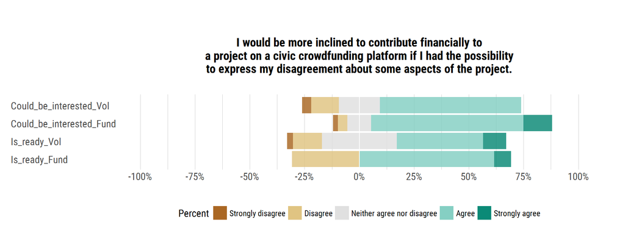

```r
t_p4 <- prop.table(table(survey_df_c$interest[survey_df_c$interest != "Not_interested"], survey_df_c$p4[survey_df_c$interest != "Not_interested"]), 1)
p4_title <- "\nI would be more inclined to contribute financially to\na project on a civic crowdfunding platform if I had the possibility\nto express my disagreement about some aspects of the project.\n"

lik_plot(t_p4, my_df_names, mylevels, factor_levels, p4_title)
```

The negative relationship identified in this last point is less clear in this plot.

#### Model 3

Let’s build a third model in which we are filtering out the observations where people are not interested in citizens initiatives, and where we split the observations into the two following groups, related to the `interest` variable:

- Class 0: `Could_be_interested_Vol` and `Is_ready_Vol`;
- Class 1: `Could_be_interested_Fund` and `Is_ready_Fund`.

In other words, we are now interested to know what factors are associated with the difference between those willing to volunteer and those willing to fund.

The rest of the model is similar to the model 1.

```r
survey_df_c_mat <- survey_df_c %>%
  filter(gender %in% c("Female", "Male")) %>%
  filter(interest != "Not_interested") %>%
  mutate(interest_binary = ifelse(interest %in% c("Is_ready_Vol",
                                                  "Could_be_interested_Vol"),
                                  0,
                                  1)) %>%
  select(interest_binary, language, p1:edu, -invest) %>%
  data.matrix() %>%
  as_data_frame()

glm3 <- glm(interest_binary ~ .,  family = "binomial",
                  data = survey_df_c_mat)

summary(glm3)
```

```
##
## Call:
## glm(formula = interest_binary ~ ., family = "binomial", data = survey_df_c_mat)
##
## Deviance Residuals:
##    Min      1Q  Median      3Q     Max
## -1.743  -0.869  -0.497   0.993   2.120
##
## Coefficients:
##             Estimate Std. Error z value Pr(>|z|)
## (Intercept)  -2.8005     2.9507   -0.95    0.343
## language     -0.0840     0.3341   -0.25    0.801
## p1            0.4846     0.2081    2.33    0.020 *
## p2           -0.2998     0.2137   -1.40    0.161
## p3           -0.2339     0.2104   -1.11    0.266
## p4            0.5874     0.2482    2.37    0.018 *
## p5           -0.2857     0.1980   -1.44    0.149
## g1            0.1327     0.2354    0.56    0.573
## g2           -0.1770     0.1968   -0.90    0.369
## g3           -0.2764     0.2049   -1.35    0.177
## g4            0.3355     0.2667    1.26    0.208
## g5           -0.3865     0.2565   -1.51    0.132
## g6            0.0634     0.2883    0.22    0.826
## neighb        0.0558     0.2108    0.26    0.791
## loc           0.0818     0.2714    0.30    0.763
## gender        0.2298     0.4192    0.55    0.583
## age           0.0862     0.1690    0.51    0.610
## edu           0.2534     0.2742    0.92    0.355
## ---
## Signif. codes:  0 '***' 0.001 '**' 0.01 '*' 0.05 '.' 0.1 ' ' 1
##
## (Dispersion parameter for binomial family taken to be 1)
##
##     Null deviance: 194.91  on 143  degrees of freedom
## Residual deviance: 161.57  on 126  degrees of freedom
## AIC: 197.6
##
## Number of Fisher Scoring iterations: 4
```

We have two variables for which the p-value of the coefficient is less than 0.05. Let’s extract them into the following table, which is ordered by `estimate` in descending order:

```r
options(scipen = 999, digits = 3)

glm3 %>%
  tidy() %>%
  filter(p.value < 0.05) %>%
  arrange(desc(estimate)) %>%
  kable() %>%
  kable_styling(bootstrap_options = c("striped", "hover"),
                full_width = F, position = "left", font_size = 14)
```

| term | estimate | std.error | statistic | p.value |
| --- | --- | --- | --- | --- |
| p4 | 0.587 | 0.248 | 2.37 | 0.018 |
| p1 | 0.485 | 0.208 | 2.33 | 0.020 |

We can interpret this table as follows:

1. Since the effect size associated with the variable `p4` is positive, then people agreeing with the statement: **I would be more inclined to contribute financially to a project on a civic crowdfunding platform if I had the possibility to express my disagreement about some aspects of the project** are more likely to be willing to fund rather than to volunteer, *after controlling for the other variables in the model*.

Let’s have a look at a plot similar to what we did in the EDA, but without the category `Not_interested` and with the class labels for the dependent variable re-ordered (on the y axis):

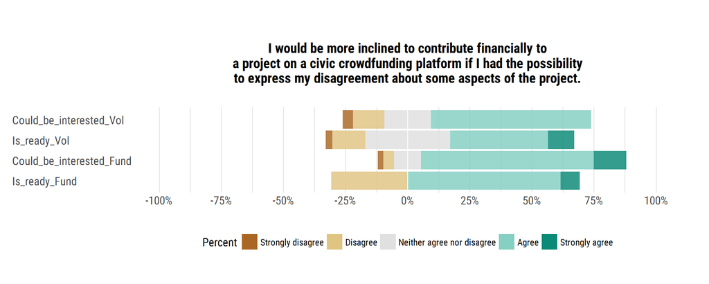

```r
t_p4 <- prop.table(table(survey_df_c$interest[survey_df_c$interest != "Not_interested"], survey_df_c$p4[survey_df_c$interest != "Not_interested"]), 1)
p4_title <- "\nI would be more inclined to contribute financially to\na project on a civic crowdfunding platform if I had the possibility\nto express my disagreement about some aspects of the project.\n"

factor_levels_m3 <- c("Could_be_interested_Vol", "Is_ready_Vol", "Could_be_interested_Fund", "Is_ready_Fund")
lik_plot(t_p4, my_df_names, mylevels, factor_levels_m3, p4_title)
```

This confirms visually the positive relationship identified in point 1, and it seems to make more sense, visually, than the relationship identified in point 5 when interpreting the model 2.

2. Similarly, since the effect size associated with the variable `p1` is positive, then people agreeing with the statement: **Personally funding a citizen’s initiative is enough to satisfy my desire to engage in this project** are more likely to be willing to fund rather than to volunteer, *after controlling for the other variables in the model*.

Let’s have a look at a plot similar to what we did in the EDA, but without the category `Not_interested` and with the class labels for the dependent variable re-ordered:

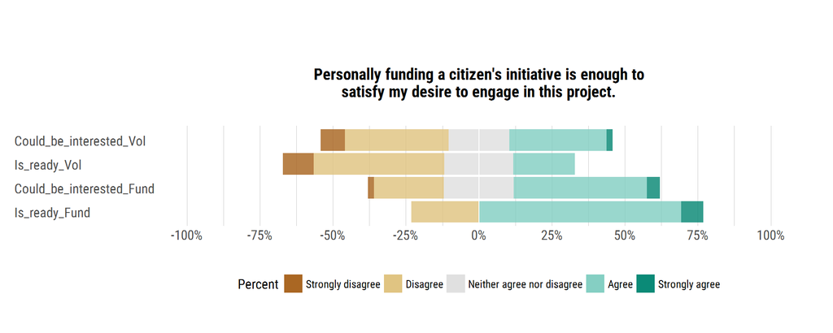

```r
t_p1 <- prop.table(table(survey_df_c$interest[survey_df_c$interest != "Not_interested"], survey_df_c$p1[survey_df_c$interest != "Not_interested"]), 1)
p1_title <- "\n\nPersonally funding a citizen's initiative is enough to\nsatisfy my desire to engage in this project.\n"

factor_levels_m3 <- c("Could_be_interested_Vol", "Is_ready_Vol", "Could_be_interested_Fund", "Is_ready_Fund")
lik_plot(t_p1, my_df_names, mylevels, factor_levels_m3, p1_title)
```

This confirms visually the positive relationship identified in point 2.

### Logistic regression with past investment as the target variable

#### Model 4

In our last model, we are going to change our target variable. Instead of modeling the interest in citizens initiatives explained by all of the other variables, we will be modeling the respondents’ past investment in citizens initiatives explained by all of the other variables (independent variables and control variables).

In order for this target to be binary, we will split the observations into the two following groups, related to the `invest` variable:

- Class 0: `0`, that is, the respondent did not report already investing in citizens initiatives;
- Class 1: All of the other choices (`1_99`, `100_199`, `200_499`, `500_plus`).

All of the other settings are the same as for the model 1.

```r
survey_df_c_mat <- survey_df_c %>%
  filter(gender %in% c("Female", "Male")) %>%
  filter(invest != "") %>%
  mutate(invest_binary = ifelse(invest == "0", 0, 1)) %>%
  select(invest_binary, language, p1:edu, -invest) %>%
  data.matrix() %>%
  as_data_frame()

glm4 <- glm(invest_binary ~ .,  family = "binomial",
            data = survey_df_c_mat)

summary(glm4)
```

```
##
## Call:
## glm(formula = invest_binary ~ ., family = "binomial", data = survey_df_c_mat)
##
## Deviance Residuals:
##    Min      1Q  Median      3Q     Max
## -1.738  -0.971  -0.514   0.950   2.413
##
## Coefficients:
##             Estimate Std. Error z value Pr(>|z|)
## (Intercept)  0.79136    2.92178    0.27   0.7865
## language     0.02150    0.34018    0.06   0.9496
## p1           0.20232    0.21531    0.94   0.3474
## p2           0.65330    0.24957    2.62   0.0089 **
## p3           0.05238    0.21171    0.25   0.8046
## p4          -0.42688    0.25583   -1.67   0.0952 .
## p5           0.03403    0.21480    0.16   0.8741
## g1          -0.49469    0.27726   -1.78   0.0744 .
## g2           0.10823    0.20656    0.52   0.6003
## g3           0.05635    0.20918    0.27   0.7876
## g4          -0.25723    0.25098   -1.02   0.3054
## g5           0.08609    0.26612    0.32   0.7463
## g6          -0.40861    0.31412   -1.30   0.1933
## neighb       0.35190    0.22921    1.54   0.1247
## loc         -0.00567    0.27556   -0.02   0.9836
## gender      -0.51515    0.44109   -1.17   0.2428
## age         -0.13074    0.18507   -0.71   0.4799
## edu         -0.01773    0.27137   -0.07   0.9479
## ---
## Signif. codes:  0 '***' 0.001 '**' 0.01 '*' 0.05 '.' 0.1 ' ' 1
##
## (Dispersion parameter for binomial family taken to be 1)
##
##     Null deviance: 175.44  on 127  degrees of freedom
## Residual deviance: 146.42  on 110  degrees of freedom
## AIC: 182.4
##
## Number of Fisher Scoring iterations: 4
```

We have a single variable for which the p-value of the coefficient is less than 0.05. Let’s extract it into the following table:

```r
options(scipen = 999, digits = 3)

glm4 %>%
  tidy() %>%
  filter(p.value < 0.05) %>%
  arrange(desc(estimate)) %>%
  kable() %>%
  kable_styling(bootstrap_options = c("striped", "hover"),
                full_width = F, position = "left", font_size = 14)
```

| term | estimate | std.error | statistic | p.value |
| --- | --- | --- | --- | --- |
| p2 | 0.653 | 0.25 | 2.62 | 0.009 |

We can interpret this result as follows:

1. Since the effect size associated with the variable `p2` is positive, then people agreeing with the statement: **I would like to participate in debates on local public issues** are more likely to be already investing in citizens initiatives than not investing, *after controlling for the other variables in the model*.

Let’s re-examine a plot that we already showed in the Exploratory Data Analysis:

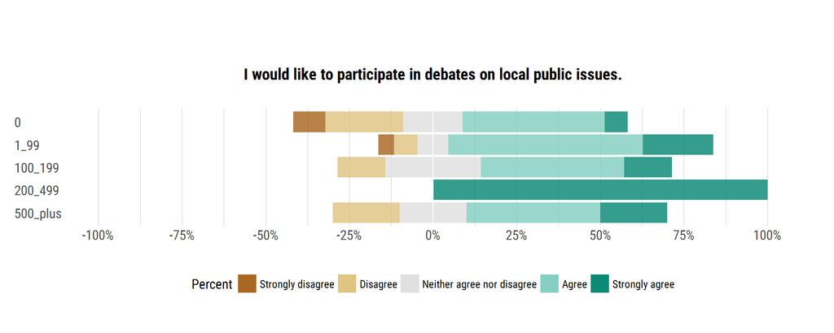

```r
t_p2 <- prop.table(table(survey_df_c_inv$invest, survey_df_c_inv$p2), 1)
p2_title <- "\n\nI would like to participate in debates on local public issues.\n"

lik_plot(t_p2, my_df_names_c_inv, mylevels_c_inv,
         factor_levels_c_inv, p2_title)
```

As a reminder from the EDA, observations where the investment is `0` represent about 57% of the sample.

From this plot we can visually confirm the result from the model 4.

# Confirmatory Factor Analysis

### Introduction

This chapter is optionnal for the reader, because we are not confident that our results are correct. We intend to update this part of the document in the future as our knowledge about dimensionality reduction techniques, factor analyis and structural equation modeling evolves.

By design, there are questions that are intended to collectively measure one latent variable. For example, there are five questions related to the wish from the citizens for more participation in debates on public issues. Also, there are six questions related to whether a civic crowdfunding platform could be regarded as an intermediary between the citizens initiatives and the local authorities.

Confirmatory Factor Analysis (CFA) allows us to reduce the dimensionality of several items into their corresponding hypothesized latent variable. The resulting latent variable is a continuous numeric variable that captures the variability of its corresponding items.

Let’s try it out.

### Preprocessing

As a reminder, here below are the questions related to the two latent variables (p for participative and g for relationship between citizens initiatives and the government):

```r
meta <- data_frame(question = header_lookup$google_f_header[17:27],
                   variable = names(survey_df_c)[5:15])

meta %>%
  kable() %>%
  kable_styling(bootstrap_options = c("striped", "hover"),
                full_width = T, font_size = 14)
```

| question | variable |
| --- | --- |
| Personally funding a citizen’s initiative is enough to satisfy my desire to engage in this project. | p1 |
| I would like to participate in debates on local public issues. | p2 |
| It is relatively easy for citizens to find places where local public issues are collectively debated. | p3 |
| I would be more inclined to contribute financially to a project on a civic crowdfunding platform if I had the possibility to express my disagreement about some aspects of the project. | p4 |
| Face-to-face interactions are necessary for collective action. | p5 |
| Civic crowdfunding represents a direct threat to public funding of services. | g1 |
| I regard crowdfunded citizen’s initiatives as a sort of *Do-It-Yourself government*. | g2 |
| The local government is able to identify the projects that are most wanted by citizens. | g3 |
| Civic crowdfunding platforms could play a role of intermediary between citizen’s initiatives and the local government. | g4 |
| General interest issues are addressed more efficiently by crowdfunded citizen’s initiatives than by the local government. | g5 |
| General interest issues are addressed more efficiently by crowdfunded citizen’s initiatives than by non-profit organizations subsidized by the local government. | g6 |

After converting the categorical variables into an integer value, we can have a look at the first ten observations:

```r
survey_df_c_mat <- survey_df_c %>%
  filter(gender %in% c("Female", "Male")) %>%
  select(language:edu) %>%
  data.matrix() %>%
  as_data_frame()

survey_df_c_mat %>%
  select(interest:neighb, age, edu, loc, gender) %>%
  head(n = 10) %>%
  kable() %>%
  kable_styling(bootstrap_options = c("striped", "hover"),
                full_width = T, font_size = 14)
```

| interest | p1 | p2 | p3 | p4 | p5 | g1 | g2 | g3 | g4 | g5 | g6 | invest | neighb | age | edu | loc | gender |
| --- | --- | --- | --- | --- | --- | --- | --- | --- | --- | --- | --- | --- | --- | --- | --- | --- | --- |
| 2 | 2 | 2 | 2 | 4 | 4 | 2 | 3 | 2 | 4 | 2 | 2 | 1 | 4 | 4 | 5 | 1 | 1 |
| 2 | 3 | 3 | 2 | 2 | 4 | 1 | 4 | 2 | 4 | 4 | 4 | 1 | 4 | 6 | 6 | 1 | 2 |
| 4 | 2 | 4 | 2 | 3 | 5 | 4 | 4 | 2 | 5 | 3 | 3 | 1 | 5 | 5 | 4 | 1 | 2 |
| 2 | 3 | 3 | 3 | 3 | 4 | 2 | 3 | 3 | 4 | 4 | 4 | 1 | 3 | 8 | 3 | 2 | 2 |
| 3 | 3 | 3 | 2 | 4 | 1 | 4 | 3 | 2 | 3 | 3 | 4 | 1 | 4 | 6 | 5 | 1 | 2 |
| 3 | 4 | 5 | 4 | 4 | 4 | 2 | 5 | 2 | 4 | 4 | 2 | 1 | 4 | 4 | 5 | 1 | 1 |
| 3 | 2 | 4 | 2 | 5 | 2 | 2 | 2 | 2 | 4 | 2 | 4 | 1 | 2 | 4 | 2 | 1 | 2 |
| 4 | 3 | 4 | 2 | 3 | 4 | 3 | 2 | 3 | 4 | 2 | 2 | 1 | 4 | 5 | 5 | 1 | 1 |
| 4 | 4 | 5 | 2 | 4 | 4 | 2 | 1 | 2 | 2 | 2 | 1 | 1 | 5 | 4 | 5 | 1 | 1 |
| 3 | 4 | 2 | 1 | 4 | 4 | 2 | 2 | 2 | 5 | 3 | 3 | 1 | 2 | 4 | 5 | 1 | 1 |

Note that the following variables were not displayed in this table because they didn’t fit into the webpage: `language` and `grouping`.

### Modeling

#### Initial model

In order to perform the CFA, we will use the lavaan (**la**tent **va**riable **an**alysis) R package.

First we need to describe the model that we want to fit. We will use the variable names `partcip_will` and `civic_crowd_gov` to refer to the wish from the citizens for more participation in debates on public issues and whether a civic crowdfunding platform could be regarded as an intermediary between the citizens initiatives and the local authorities, respectively.

```r
model <- "
partcip_will =~ p2 + p1 + p3 + p4 + p5
civic_crowd_gov =~ g4 + g1 + g2 + g3 + g5 + g6
"

cat(model)
```

```
##
## partcip_will =~ p2 + p1 + p3 + p4 + p5
## civic_crowd_gov =~ g4 + g1 + g2 + g3 + g5 + g6
```

Next, we can fit this model using the `cfa()` function and look at the summary statistics.

```r
fit1 <- cfa(model = model, data = survey_df_c_mat)

summary(fit1, standardized = TRUE)
```

```
## lavaan (0.5-23.1097) converged normally after  93 iterations
##
##   Number of observations                           151
##
##   Estimator                                         ML
##   Minimum Function Test Statistic               60.181
##   Degrees of freedom                                43
##   P-value (Chi-square)                           0.043
##
## Parameter Estimates:
##
##   Information                                 Expected
##   Standard Errors                             Standard
##
## Latent Variables:
##                      Estimate  Std.Err  z-value  P(>|z|)   Std.lv  Std.all
##   partcip_will =~
##     p2                  1.000                               0.270    0.247
##     p1                  0.294    0.284    1.035    0.300    0.080    0.076
##     p3                 -0.322    0.267   -1.205    0.228   -0.087   -0.090
##     p4                  4.006    4.250    0.943    0.346    1.084    1.144
##     p5                  0.180    0.290    0.620    0.535    0.049    0.044
##   civic_crowd_gov =~
##     g4                  1.000                               0.106    0.127
##     g1                  0.408    0.840    0.486    0.627    0.043    0.050
##     g2                  1.901    1.730    1.099    0.272    0.202    0.179
##     g3                 -1.867    1.647   -1.134    0.257   -0.198   -0.198
##     g5                  5.622    4.254    1.322    0.186    0.596    0.635
##     g6                  6.347    4.874    1.302    0.193    0.673    0.802
##
## Covariances:
##                    Estimate  Std.Err  z-value  P(>|z|)   Std.lv  Std.all
##   partcip_will ~~
##     civic_crowd_gv    0.008    0.011    0.741    0.459    0.288    0.288
##
## Variances:
##                    Estimate  Std.Err  z-value  P(>|z|)   Std.lv  Std.all
##    .p2                1.126    0.149    7.573    0.000    1.126    0.939
##    .p1                1.078    0.124    8.688    0.000    1.078    0.994
##    .p3                0.921    0.106    8.681    0.000    0.921    0.992
##    .p4               -0.276    1.180   -0.234    0.815   -0.276   -0.308
##    .p5                1.192    0.137    8.692    0.000    1.192    0.998
##    .g4                0.683    0.079    8.635    0.000    0.683    0.984
##    .g1                0.760    0.088    8.681    0.000    0.760    0.998
##    .g2                1.224    0.143    8.578    0.000    1.224    0.968
##    .g3                0.964    0.113    8.552    0.000    0.964    0.961
##    .g5                0.526    0.110    4.775    0.000    0.526    0.597
##    .g6                0.252    0.120    2.101    0.036    0.252    0.357
##     partcip_will      0.073    0.087    0.841    0.400    1.000    1.000
##     civic_crowd_gv    0.011    0.017    0.669    0.504    1.000    1.000
```

Then, we can extract the standardized parameter estimates as follows.

```r
options(scipen = 999, digits = 3)

sfit1 <- standardizedsolution(fit1)

sfit1 %>%
  filter(op == "=~") %>%
  kable() %>%
  kable_styling(bootstrap_options = c("striped", "hover"),
                full_width = T, font_size = 14)
```

| lhs | op | rhs | est.std | se | z | pvalue |
| --- | --- | --- | --- | --- | --- | --- |
| partcip_will | =~ | p2 | 0.247 | 0.145 | 1.706 | 0.088 |
| partcip_will | =~ | p1 | 0.076 | 0.081 | 0.938 | 0.348 |
| partcip_will | =~ | p3 | -0.090 | 0.085 | -1.059 | 0.290 |
| partcip_will | =~ | p4 | 1.144 | 0.575 | 1.989 | 0.047 |
| partcip_will | =~ | p5 | 0.044 | 0.075 | 0.597 | 0.551 |
| civic_crowd_gov | =~ | g4 | 0.127 | 0.094 | 1.350 | 0.177 |
| civic_crowd_gov | =~ | g1 | 0.050 | 0.095 | 0.521 | 0.602 |
| civic_crowd_gov | =~ | g2 | 0.179 | 0.093 | 1.919 | 0.055 |
| civic_crowd_gov | =~ | g3 | -0.198 | 0.093 | -2.127 | 0.033 |
| civic_crowd_gov | =~ | g5 | 0.635 | 0.095 | 6.656 | 0.000 |
| civic_crowd_gov | =~ | g6 | 0.802 | 0.107 | 7.504 | 0.000 |

Finally, we can extract the most important fit statistics as follows.

```r
fit_1 <- fitmeasures(fit1, c("npar", "chisq", "df", "cfi", "rmsea", "srmr"))

cbind(read.table(text = names(fit_1)), fit_1) %>%
  select(fit_1) %>%
  kable() %>%
  kable_styling(bootstrap_options = c("striped", "hover"),
                full_width = F, position = "left", font_size = 14)
```

|  | fit_1 |
| --- | --- |
| npar | 23.0000 |
| chisq | 60.1812 |
| df | 43.0000 |
| cfi | 0.8058 |
| rmsea | 0.0514 |
| srmr | 0.0731 |

#### Model improvement

Modification indices can be requested in order to determine if changes should be made to the model such as adding error covariance terms or removing poor performing items, in order to improve the model. Here, we sorted the output by `mi` in decreasing order.

```r
modificationindices(fit1) %>%
  arrange(desc(mi)) %>%
  head(10) %>%
  kable() %>%
  kable_styling(bootstrap_options = c("striped", "hover"),
                full_width = T, font_size = 14)
```

| lhs | op | rhs | mi | epc | sepc.lv | sepc.all | sepc.nox |
| --- | --- | --- | --- | --- | --- | --- | --- |
| p1 | ~~ | p5 | 12.89 | -0.331 | -0.331 | -0.291 | -0.291 |
| p3 | ~~ | g2 | 6.65 | 0.224 | 0.224 | 0.206 | 0.206 |
| g1 | ~~ | g2 | 6.54 | 0.202 | 0.202 | 0.206 | 0.206 |
| p5 | ~~ | g1 | 5.25 | 0.177 | 0.177 | 0.186 | 0.186 |
| p2 | ~~ | g4 | 2.34 | 0.108 | 0.108 | 0.119 | 0.119 |
| p5 | ~~ | g4 | 2.25 | 0.110 | 0.110 | 0.121 | 0.121 |
| p2 | ~~ | p5 | 2.25 | 0.142 | 0.142 | 0.118 | 0.118 |
| g4 | ~~ | g6 | 2.14 | -0.090 | -0.090 | -0.129 | -0.129 |
| p2 | ~~ | g6 | 1.71 | -0.092 | -0.092 | -0.100 | -0.100 |
| p2 | ~~ | p1 | 1.59 | -0.116 | -0.116 | -0.102 | -0.102 |

In the lavaan package, `~~` means covariance terms. Let’s add `p1 ~~ p5` and see if the model improves.

```r
model2 <- "
partcip_will =~ p2 + p1 + p3 + p4 + p5
civic_crowd_gov =~ g4 + g1 + g2 + g3 + g5 + g6
p1 ~~ p5
"

cat(model2)
```

```
##
## partcip_will =~ p2 + p1 + p3 + p4 + p5
## civic_crowd_gov =~ g4 + g1 + g2 + g3 + g5 + g6
## p1 ~~ p5
```

```r
fit2 <- cfa(model = model2, data = survey_df_c_mat)

fits <- list(fit_1 = fit1, fit_2 = fit2)

round(sapply(fits, function(X)
  fitmeasures(X, c("npar", "chisq", "df", "cfi", "rmsea", "srmr"))), 3) %>%
  kable() %>%
  kable_styling(bootstrap_options = c("striped", "hover"),
                full_width = F, position = "left", font_size = 14)
```

|  | fit_1 | fit_2 |
| --- | --- | --- |
| npar | 23.000 | 24.000 |
| chisq | 60.181 | 46.640 |
| df | 43.000 | 42.000 |
| cfi | 0.806 | 0.948 |
| rmsea | 0.051 | 0.027 |
| srmr | 0.073 | 0.063 |

Instead of qualitatively assessing this improvement, we can perform a significance test to compare the two models.

```r
anova(fit1, fit2)
```

```
## Chi Square Difference Test
##
##      Df  AIC  BIC Chisq Chisq diff Df diff Pr(>Chisq)
## fit2 42 4572 4644  46.6
## fit1 43 4583 4653  60.2       13.5       1    0.00023 ***
## ---
## Signif. codes:  0 '***' 0.001 '**' 0.01 '*' 0.05 '.' 0.1 ' ' 1
```

As evidenced by the p-value that is below 0.05, it seems that adding the covariance term significantly improved the model. We will then consider this latter model for the rest of this analysis.

We can now save the latent variables and add them to our dataset. In the following two tables we show, for the first six observations, the items `p1` to `p5` along with their corresponding latent variable, as well as the items `g1` to `g6` along with their own latent variable.

```r
pfit2 <- data.frame(predict(fit2))
survey_df_c_mat2 <- cbind(survey_df_c_mat, pfit2)

survey_df_c <- survey_df_c %>%
  filter(gender %in% c("Female", "Male")) %>%
  cbind(partcip_will = survey_df_c_mat2$partcip_will,
        civic_crowd_gov = survey_df_c_mat2$civic_crowd_gov)

survey_df_c %>%
  select(p1:p5, partcip_will) %>%
  head() %>%
  kable() %>%
  kable_styling(bootstrap_options = c("striped", "hover"),
                full_width = T, font_size = 14)
```

| p1 | p2 | p3 | p4 | p5 | partcip_will |
| --- | --- | --- | --- | --- | --- |
| Disagree | Disagree | Disagree | Agree | Agree | 0.136 |
| Neither agree nor disagree | Neither agree nor disagree | Disagree | Disagree | Agree | -0.489 |
| Disagree | Agree | Disagree | Neither agree nor disagree | Strongly agree | -0.169 |
| Neither agree nor disagree | Neither agree nor disagree | Neither agree nor disagree | Neither agree nor disagree | Agree | -0.169 |
| Neither agree nor disagree | Neither agree nor disagree | Disagree | Agree | Strongly disagree | 0.149 |
| Agree | Strongly agree | Agree | Agree | Agree | 0.154 |

```r
survey_df_c %>%
  select(g1:g6, civic_crowd_gov) %>%
  head() %>%
  kable() %>%
  kable_styling(bootstrap_options = c("striped", "hover"),
                full_width = T, font_size = 14)
```

| g1 | g2 | g3 | g4 | g5 | g6 | civic_crowd_gov |
| --- | --- | --- | --- | --- | --- | --- |
| Disagree | Neither agree nor disagree | Disagree | Agree | Disagree | Disagree | -0.101 |
| Strongly disagree | Agree | Disagree | Agree | Agree | Agree | 0.105 |
| Agree | Agree | Disagree | Strongly agree | Neither agree nor disagree | Neither agree nor disagree | 0.014 |
| Disagree | Neither agree nor disagree | Neither agree nor disagree | Agree | Agree | Agree | 0.107 |
| Agree | Neither agree nor disagree | Disagree | Neither agree nor disagree | Neither agree nor disagree | Agree | 0.088 |
| Disagree | Strongly agree | Disagree | Agree | Agree | Disagree | -0.019 |

### Analysis using latent variables

#### Qualitative assessment of the relationship between dependent and independent variables

Let’s see now if we can better assess the relationship between our independent variables (`partcip_will` and `civic_crowd_gov`) and our dependent variable, which is the degree of interest from citizens in citizens initiatives.

Our independent variables are now reduced to a continuous numeric value, thus we can use boxplots to explore the relationships visually.

[figure not shown]

```r
survey_df_c %>%
  ggplot(aes(y = partcip_will, x = interest, fill = interest)) +
  geom_boxplot(alpha = .5) +
  labs(title = "Relationship btw particip_will and interest",
       x = "") +
  theme_ipsum_rc() +
  scale_fill_ipsum() +
  theme(panel.grid.major.y = element_blank(),
        panel.grid.minor.y = element_blank()) +
  coord_flip() +
  theme(plot.title = element_text(size = 14, hjust = 0.5)) +
  theme(axis.text.y = element_text(hjust = 0)) +
  theme(plot.margin = unit(c(1,1,1,0), "cm"))
```

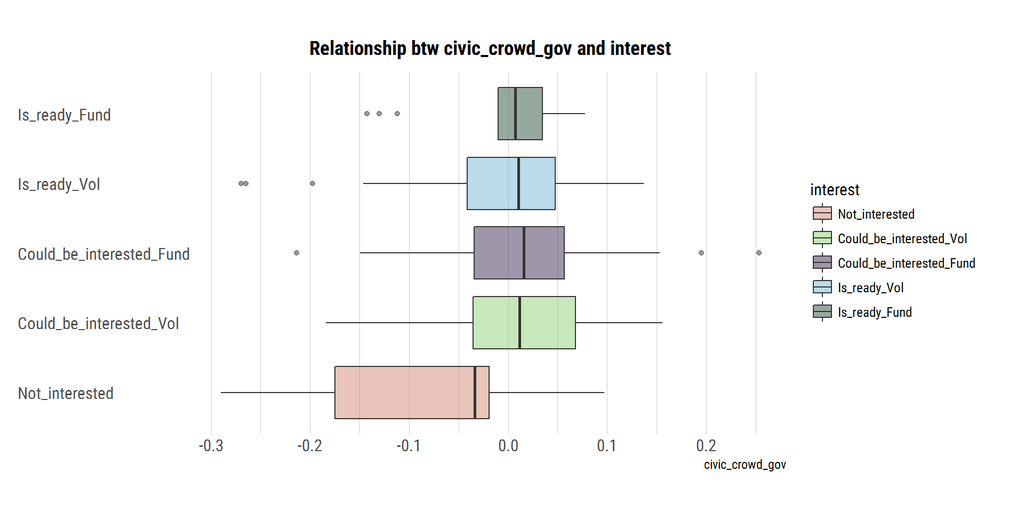

```r
survey_df_c %>%
  ggplot(aes(y = civic_crowd_gov, x = interest, fill = interest)) +
  geom_boxplot(alpha = .5) +
  labs(title = "Relationship btw civic_crowd_gov and interest",
       x = "") +
  theme_ipsum_rc() +
  scale_fill_ipsum() +
  theme(panel.grid.major.y = element_blank(),
        panel.grid.minor.y = element_blank()) +
  coord_flip() +
  theme(plot.title = element_text(size = 14, hjust = 0.5)) +
  theme(axis.text.y = element_text(hjust = 0)) +
  theme(plot.margin = unit(c(1,1,1,0), "cm"))
```

From these two plots, we can qualitatively assess that:

- negative values of both independent variables could be associated with not being interested in citizens initiatives;
- there does not seem to be a significant difference between the other categories of interest: they are all associated with values of the latent variables centered at or above zero.

Again, we are not claiming here that these results are correct and we will not include them in our conclusions. We will refine this part of the document further in the next following months.

# Exploratory Data Analysis

Our sample frame here is all active members (whom we simply call ‘entrepreneurs’ in this document) of a local citizens initiative, social project or social organization in the Brussels-Capital Region.

### Control variables

The EDA of the control variables for the entrepreneurs was shared with the EDA of the control variables for the citizens. Therefore, please refer back to that section if needed.

### Dependent and independent variables

Concerning the entrepeneurs (active members of a local citizens initiative, social project or social organization), the objective of this survey is to test two hypotheses that were derived from our qualitative research:

1. H1: A more participative platform is positively correlated with the interest to join a civic crowdfunding platform.
2. H2: A positive opinion on projects that are co-created by social entrepreneurs and the local government is positively correlated with the interest to join a civic crowdfunding platform.

The interest to join a civic crowdfunding platform is thus our dependent variable (this is the outcome that BrusselsTogether would like to better understand) and is measured by the question shown in the table below. Also shown in this table is the related categories in the R code.

```r
x <- list(q = names(lut_e_int_eng), v = levels(survey_df_e$interest)) %>% as_data_frame()
colnames(x) <- c(header_lookup$google_f_header[4], "Category in R code")
x %>%
  kable() %>%
  kable_styling(bootstrap_options = c("striped", "hover"),
                full_width = F, position = "left", font_size = 14)
```

| As an active member of a local citizen’s initiative, social project or social organization, please indicate your level of interest in joining a civic crowdfunding platform: | Category in R code |
| --- | --- |
| I am not interested in joining a civic crowdfunding platform. | Not_interested |
| I could be interested to join a civic crowdfunding platform. | Could_be_interested |
| I am ready to join a civic crowdfunding platform. | Is_ready |

The answers are distributed as shown in the figure below:

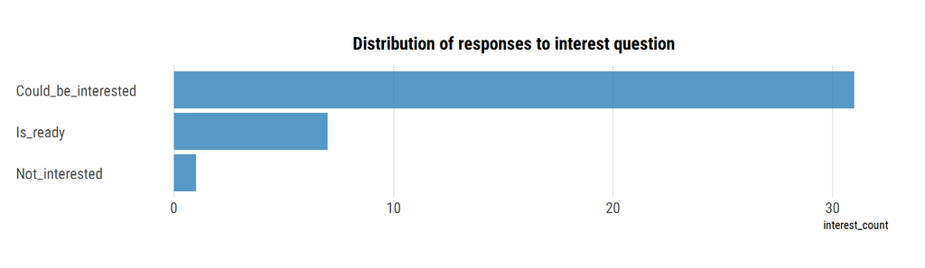

```r
survey_df_e %>%
  count(interest) %>%
  rename(interest_count = n) %>%
  mutate(interest = reorder(interest, interest_count)) %>%
  ggplot(aes(x = interest, y = interest_count)) +
  geom_col(fill = "#2C7FB8", alpha = 0.8) +
  theme_ipsum_rc(grid = "X") +
  scale_fill_ipsum() +
  coord_flip() +
  labs(title = "Distribution of responses to interest question", x = "") +
  theme(plot.title = element_text(size = 14, hjust = 0.5)) +
  theme(axis.text.y = element_text(hjust = 0)) +
  theme(plot.margin = unit(c(1,1,1,0), "cm"))
```

```r
options(scipen = 999, digits = 2)

survey_df_e %>%
  count(interest) %>%
  mutate(total = sum(n),
         percent = n / total) %>%
  select(interest, n, percent) %>%
  arrange(desc(n)) %>%
  kable() %>%
  kable_styling(bootstrap_options = c("striped", "hover"),
                full_width = F, position = "left", font_size = 14)
```

| interest | n | percent |
| --- | --- | --- |
| Could_be_interested | 31 | 0.79 |
| Is_ready | 7 | 0.18 |
| Not_interested | 1 | 0.03 |

The independent variables (the appeal of a more participative platform for H1 and the opinion on projects that are co-created by social entrepreneurs and the local government through civic crowdfunding platforms for H2) are what we think could be associated with the dependent variable (although we could not make causal inference from an observational study like this one). If the correlations are verified, then we could provide BrusselsTogether with actionnable recommendations, such as making the platform more participative or playing a role of intermediary between citizens initiatives and the local authorities.

For each of the two independent variables, we asked a set of questions which, in our opinion, should reflect their corresponding independent variable. In this case, we could say that the independent variables are latent variables that are each measured by a set of several items.

The table below displays the items along with their related variable name in the R code. The items related to the appeal of a more participative platform are `p1` to `p5` and the items related to the opinion on projects that are co-created by social entrepreneurs and the local government through civic crowdfunding platforms are `g1` to `g6`.

Additionnaly, we asked the respondents whether their interest in contributing to the future of their neighborhood had increased in the past several years (variable name `neighb`).

All of those items were measured on a 5-points Likert scale, from `Strongly_disagree` to `Strongly_agree`.

```r
meta <- data_frame(question = header_lookup$google_f_header[c(5:15, 29)],
                   variable_name = names(survey_df_e)[c(5:16)])

meta %>%
  kable() %>%
  kable_styling(bootstrap_options = c("striped", "hover"),
                full_width = T, font_size = 14)
```

| question | variable_name |
| --- | --- |
| Face-to-face interactions are necessary for collective action. | p1 |
| For most citizens on a civic crowdfunding platform, personnally funding a citizen’s initiative is enough to satisfy their desire to engage in this project. | p2 |
| Citizens would like to participate in debates on local public issues that they care about. | p3 |
| It is relatively easy for citizens to find places where local public issues are collectively debated. | p4 |
| I would welcome the possibility for citizens on a crowdfunding platform to express their disagreement about some aspects of the projects they contribute to financially. | p5 |
| Civic crowdfunding represents a direct threat to the funding of public goods and services by the local government. | g1 |
| I regard crowdfunded citizen’s initiatives as a sort of *Do-It-Yourself government*. | g2 |
| The local government is able to identify the projects that are most wanted by citizens. | g3 |
| Civic crowdfunding platforms could play a role of intermediary between citizen’s initiatives and the local government. | g4 |
| General interest issues are addressed more efficiently by crowdfunded citizen’s initiatives than by the local government. | g5 |
| General interest issues are addressed more efficiently by crowdfunded citizen’s initiatives than by non-profit organizations subsidized by the local government. | g6 |
| My interest in contributing to the future of my neighborhood has increased in the past several years. | neighb |

The answers are distributed as shown in the three plots below:

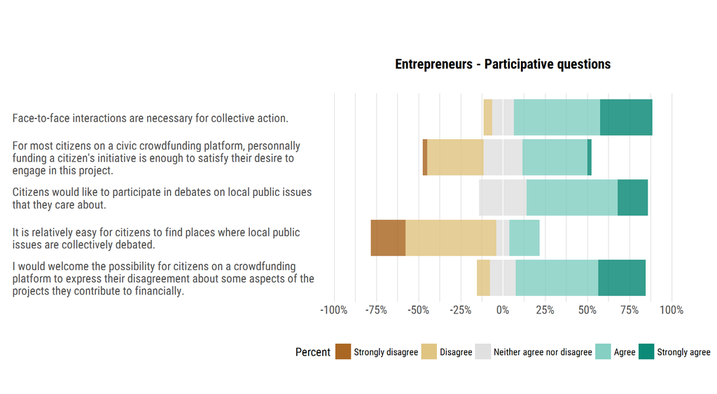

```r
questions_e <- header_lookup$google_f_header[5:15]
quest_code_e <- names(survey_df_e)[5:15]
survey_df_e_df <- as.data.frame(survey_df_e)
names(survey_df_e_df)[5:15] <- questions_e


my_df_names_e_p <- c("interest", "Strongly disagree", "Disagree", "Neither agree nor disagree",
                     "Agree", "Strongly agree")
mylevels_e_p <- c("Strongly disagree", "Disagree", "Neither agree nor disagree",
                  "Agree", "Strongly agree")
factor_levels_e_p <- c("Face-to-face interactions are necessary for collective action.",
                       "For most citizens on a civic crowdfunding platform, personnally funding a citizen's initiative is enough to satisfy their desire to engage in this project.",
                       "Citizens would like to participate in debates on local public issues that they care about.",
                       "It is relatively easy for citizens to find places where local public issues are collectively debated.",
                       "I would welcome the possibility for citizens on a crowdfunding platform to express their disagreement about some aspects of the projects they contribute to financially.")

temp_e_p <- survey_df_e_df[,5:9]

temp_e_p_gathered <- temp_e_p %>%
  gather(key = "question", value = "answer")

temp_e_p_gathered$answer <- factor(temp_e_p_gathered$answer, ordered = T,
                                   levels = mylevels_e_p)

t_e_p <- prop.table(table(temp_e_p_gathered$question,
                          temp_e_p_gathered$answer), 1)
e_p_title <- "\n\nEntrepreneurs - Participative questions\n"

lik_plot(t_e_p, my_df_names_e_p, mylevels_e_p, factor_levels_e_p, e_p_title)
```

We can observe from this plot that the responses to most questions are polarized. In particular:

- It seems that most of the respondents agree with the statement: **Face-to-face interactions are necessary for collective action.**
- It seems that most of the respondents agree with the statement: **Citizens would like to participate in debates on local public issues that they care about.**
- It seems that most of the respondents disagree with the statement: **It is relatively easy for citizens to find places where local public issues are collectively debated.**
- It seems that most of the respondents agree with the statement: **I would welcome the possibility for citizens on a crowdfunding platform to express their disagreement about some aspects of the projects they contribute to financially.**

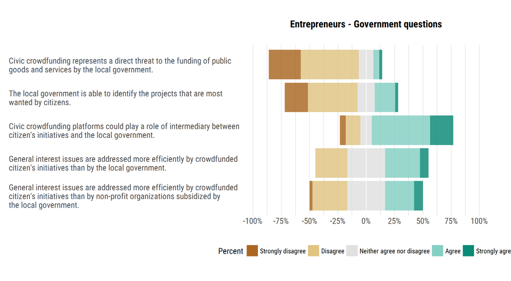

```r
my_df_names_e_g <- c("interest", "Strongly disagree", "Disagree", "Neither agree nor disagree",
                 "Agree", "Strongly agree")
mylevels_e_g <- c("Strongly disagree", "Disagree", "Neither agree nor disagree",
              "Agree", "Strongly agree")
factor_levels_e_g <- c("Civic crowdfunding represents a direct threat to the funding of public goods and services by the local government.",
                       "I regard crowdfunded citizen's initiatives as a sort of_Do-It-Yourself government_.",
                       "The local government is able to identify the projects that are most wanted by citizens.",
                       "Civic crowdfunding platforms could play a role of intermediary between citizen's initiatives and the local government.",
                       "General interest issues are addressed more efficiently by crowdfunded citizen's initiatives than by the local government.",
                       "General interest issues are addressed more efficiently by crowdfunded citizen's initiatives than by non-profit organizations subsidized by the local government.")

temp_e_g <- survey_df_e_df[,10:15]

temp_e_g_gathered <- temp_e_g %>%
  gather(key = "question", value = "answer")

temp_e_g_gathered$answer <- factor(temp_e_g_gathered$answer, ordered = T,
                                   levels = mylevels_e_g)

t_e_g <- prop.table(table(temp_e_g_gathered$question,
                          temp_e_g_gathered$answer), 1)
e_g_title <- "Entrepreneurs - Government questions\n"

lik_plot(t_e_g, my_df_names_e_g, mylevels_e_g, factor_levels_e_g, e_g_title)
```

Once again, we can observe from this plot that the responses to some questions are polarized. In particular:

- It seems that most of the respondents disagree with the statement: **Civic crowdfunding represents a direct threat to the funding of public goods and services by the local government.**
- Quite interestingly for the validation of the hypothese H2, it seems that most of the respondents agree with the statement: **Civic crowdfunding platforms could play a role of intermediary between citizen’s initiatives and the local government.**

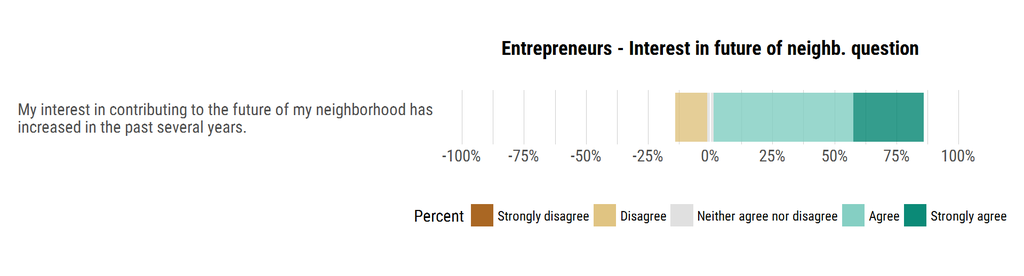

```r
questions_neighb <- header_lookup$google_f_header[29]
quest_code_neighb <- names(survey_df_e)[16]
names(survey_df_e_df)[16] <- questions_neighb

my_df_names_e_neighb <- c("interest", "Strongly disagree", "Disagree", "Neither agree nor disagree",
                          "Agree", "Strongly agree")
mylevels_e_neighb <- c("Strongly disagree", "Disagree", "Neither agree nor disagree",
                       "Agree", "Strongly agree")
factor_levels_e_neighb <- c("My interest in contributing to the future of my neighborhood has increased in the past several years.")

temp_e_neighb <- as.data.frame(survey_df_e_df[,16])
names(temp_e_neighb) <- "My interest in contributing to the future of my neighborhood has increased in the past several years."

temp_e_neighb_gathered <- temp_e_neighb %>%
  gather(key = "question", value = "answer")

temp_e_neighb_gathered$answer <- factor(temp_e_neighb_gathered$answer,
                                        ordered = T,
                                        levels = mylevels_e_neighb)

t_e_neighb <- prop.table(table(temp_e_neighb_gathered$question,
                          temp_e_neighb_gathered$answer), 1)
e_neighb_title <- "Entrepreneurs - Interest in future of neighb. question\n"

lik_plot(t_e_neighb, my_df_names_e_neighb, mylevels_e_neighb, factor_levels_e_neighb, e_neighb_title)
```

The response to this question is polarized once again, as entrepreneur seem to generally agree with the statement: **My interest in contributing to the future of my neighborhood has increased in the past several years.**

### Distribution of answers for independent variables broken down by interest

In order to have a rough sense of the relationship between, on the one hand, the answers to the indenpendent variables questions and the control variable questions, and on the other hand, the answers to the dependent variable question, in this section we are going to break down the previous vizualisations by category of answer to the dependent variable question. We will try to confirm those relationships quantitatively later on, in the chapter **Logistic Regression Modeling**.

Let us then break down the distribution of answers related to the independent variables by interest in joining a civic crowdfunding platform.

As for the analysis of the citizens responses, we should keep in mind that people ‘ready to join’ and ‘not interested’ represent only a fraction of the sample.

Here below is a series of plots related to the ‘participative’ questions.

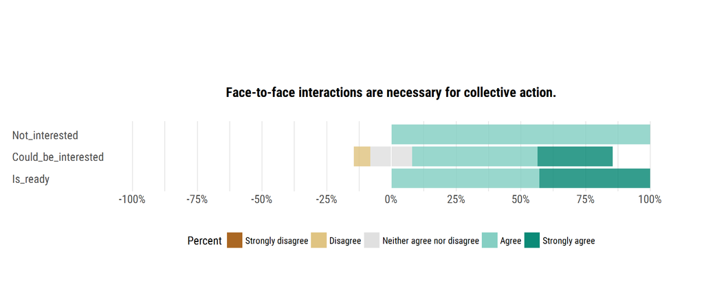

```r
my_df_names <- c("interest", "Strongly disagree", "Disagree", "Neither agree nor disagree",
                 "Agree", "Strongly agree")
mylevels <- c("Strongly disagree", "Disagree", "Neither agree nor disagree",
              "Agree", "Strongly agree")
factor_levels <- c("Not_interested",
                   "Could_be_interested",
                   "Is_ready")

t_p1 <- prop.table(table(survey_df_e$interest, survey_df_e$p1), 1)
p1_title <- "\n\n\n\nFace-to-face interactions are necessary for collective action.\n"

lik_plot(t_p1, my_df_names, mylevels, factor_levels, p1_title)
```

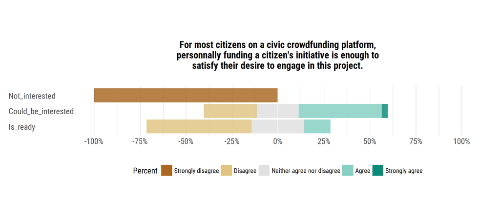

```r
t_p2 <- prop.table(table(survey_df_e$interest, survey_df_e$p2), 1)
p2_title <- "\n\nFor most citizens on a civic crowdfunding platform,\npersonnally funding a citizen's initiative is enough to\nsatisfy their desire to engage in this project.\n"

lik_plot(t_p2, my_df_names, mylevels, factor_levels, p2_title)
```

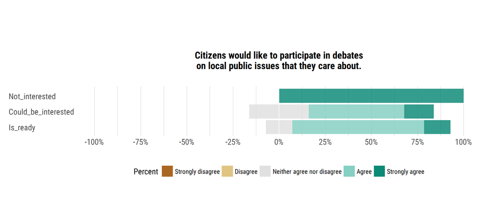

```r
t_p3 <- prop.table(table(survey_df_e$interest, survey_df_e$p3), 1)
p3_title <- "\n\n\nCitizens would like to participate in debates\non local public issues that they care about.\n"

lik_plot(t_p3, my_df_names, mylevels, factor_levels, p3_title)
```

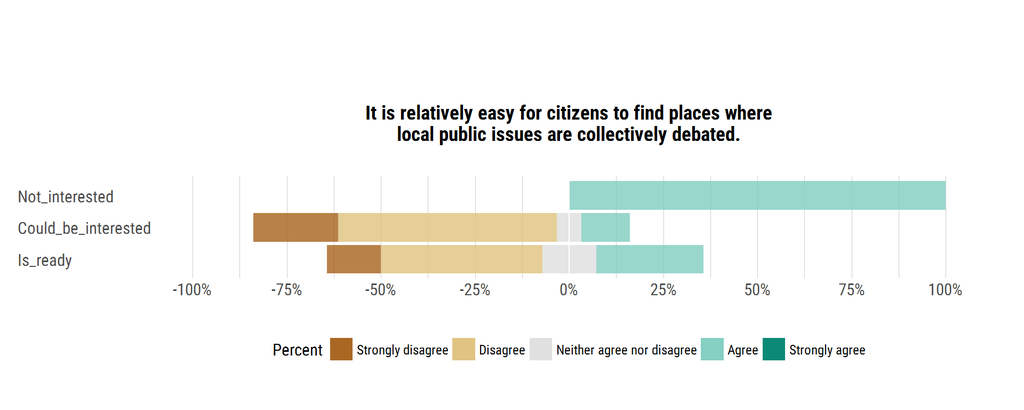

```r
t_p4 <- prop.table(table(survey_df_e$interest, survey_df_e$p4), 1)
p4_title <- "\n\n\nIt is relatively easy for citizens to find places where\nlocal public issues are collectively debated.\n"

lik_plot(t_p4, my_df_names, mylevels, factor_levels, p4_title)
```

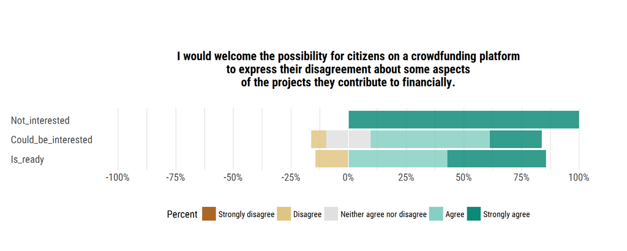

```r
t_p5 <- prop.table(table(survey_df_e$interest, survey_df_e$p5), 1)
p5_title <- "\n\nI would welcome the possibility for citizens on a crowdfunding platform\nto express their disagreement about some aspects\nof the projects they contribute to financially.\n"

lik_plot(t_p5, my_df_names, mylevels, factor_levels, p5_title)
```

Here below is a series of plots related to the ‘government’ questions.

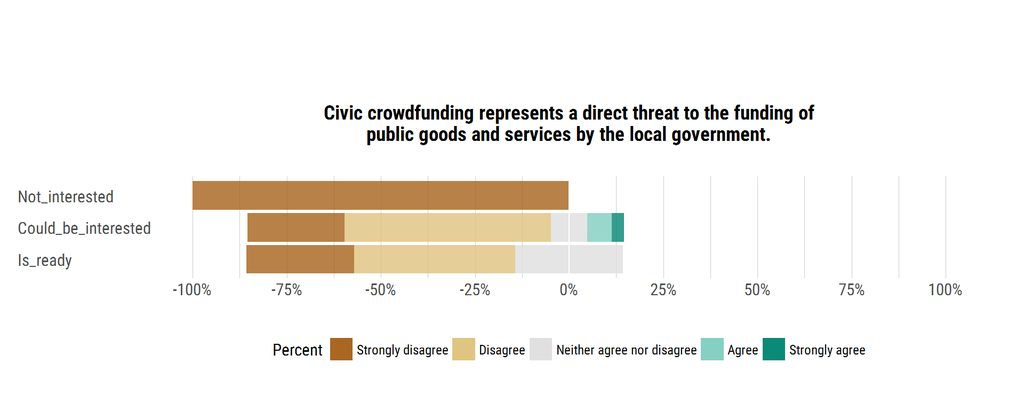

```r
my_df_names <- c("interest", "Strongly disagree", "Disagree", "Neither agree nor disagree",
                 "Agree", "Strongly agree")
mylevels <- c("Strongly disagree", "Disagree", "Neither agree nor disagree",
              "Agree", "Strongly agree")
factor_levels <- c("Not_interested",
                   "Could_be_interested",
                   "Is_ready")

t_g1 <- prop.table(table(survey_df_e$interest, survey_df_e$g1), 1)
g1_title <- "\n\n\nCivic crowdfunding represents a direct threat to the funding of\npublic goods and services by the local government.\n"

lik_plot(t_g1, my_df_names, mylevels, factor_levels, g1_title)
```

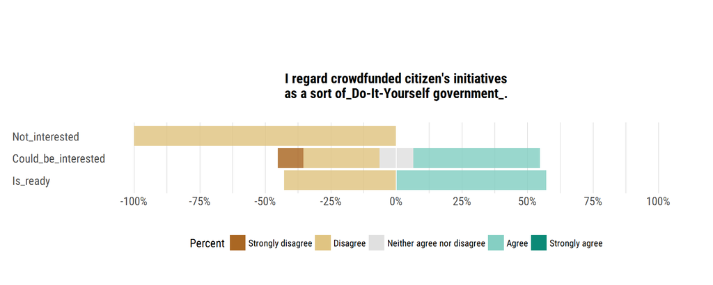

```r
t_g2 <- prop.table(table(survey_df_e$interest, survey_df_e$g2), 1)
g2_title <- "\n\n\nI regard crowdfunded citizen's initiatives\nas a sort of_Do-It-Yourself government_.\n"

lik_plot(t_g2, my_df_names, mylevels, factor_levels, g2_title)
```

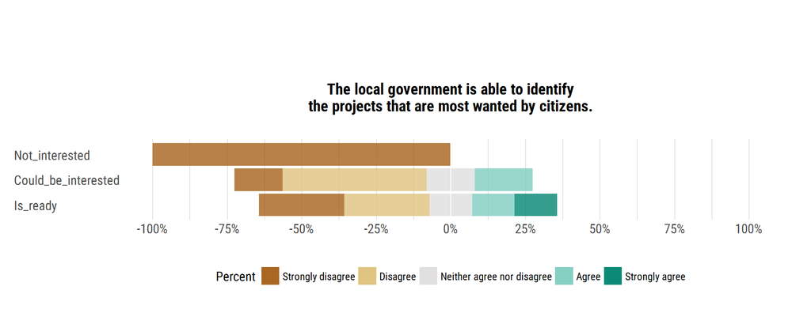

```r
t_g3 <- prop.table(table(survey_df_e$interest, survey_df_e$g3), 1)
g3_title <- "\n\n\nThe local government is able to identify\nthe projects that are most wanted by citizens.\n"

lik_plot(t_g3, my_df_names, mylevels, factor_levels, g3_title)
```

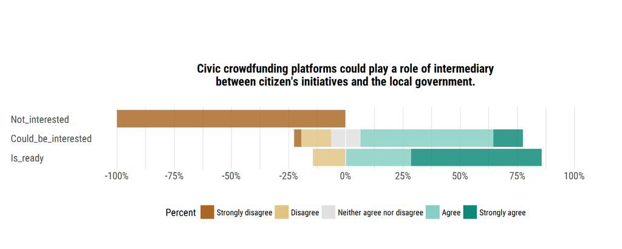

```r
t_g4 <- prop.table(table(survey_df_e$interest, survey_df_e$g4), 1)
g4_title <- "\n\n\nCivic crowdfunding platforms could play a role of intermediary\nbetween citizen's initiatives and the local government.\n"

lik_plot(t_g4, my_df_names, mylevels, factor_levels, g4_title)
```

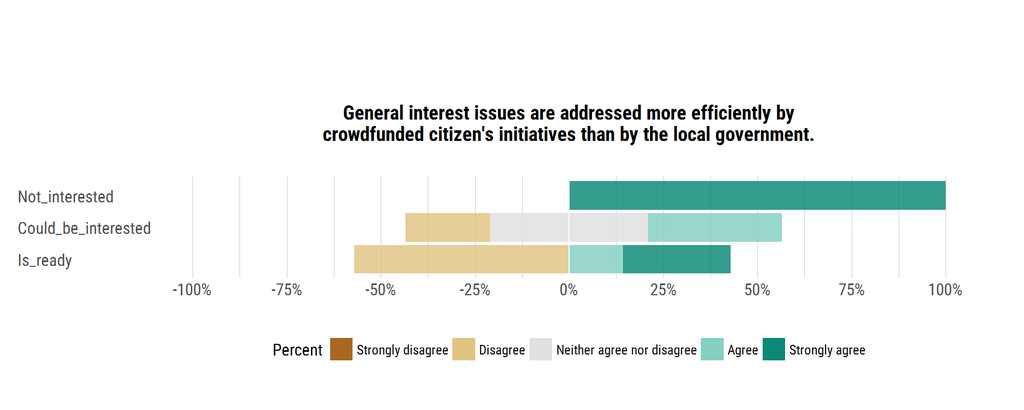

```r
t_g5 <- prop.table(table(survey_df_e$interest, survey_df_e$g5), 1)
g5_title <- "\n\n\nGeneral interest issues are addressed more efficiently by\ncrowdfunded citizen's initiatives than by the local government.\n"

lik_plot(t_g5, my_df_names, mylevels, factor_levels, g5_title)
```

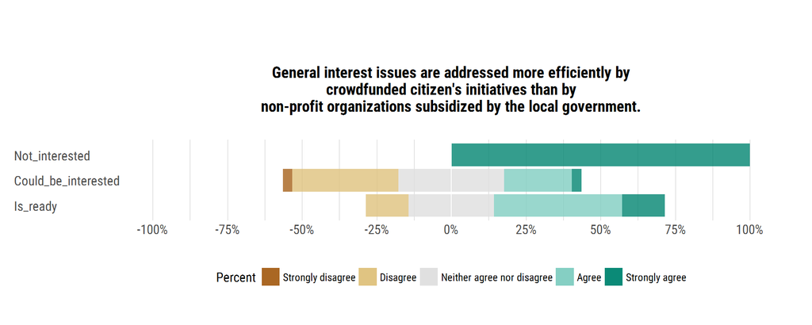

```r
t_g6 <- prop.table(table(survey_df_e$interest, survey_df_e$g6), 1)
g6_title <- "\n\nGeneral interest issues are addressed more efficiently by\ncrowdfunded citizen's initiatives than by\nnon-profit organizations subsidized by the local government.\n"

lik_plot(t_g6, my_df_names, mylevels, factor_levels, g6_title)
```

Here below is the plot related to the ‘interest in the future of my neighborhood’ question.

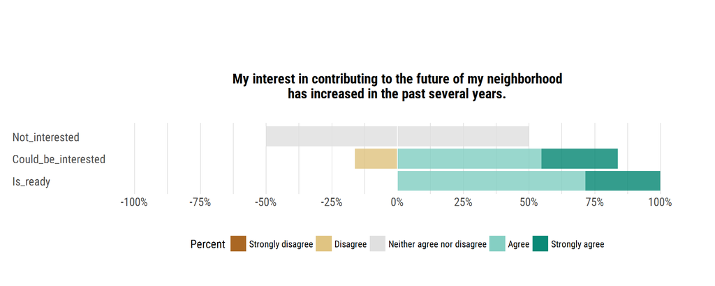

```r
t_neighb <- prop.table(table(survey_df_e$interest, survey_df_e$neighb), 1)
neighb_title <- "\n\n\nMy interest in contributing to the future of my neighborhood\nhas increased in the past several years.\n"

lik_plot(t_neighb, my_df_names, mylevels, factor_levels, neighb_title)
```

### Distribution of answers for independent variables broken down by education

Here below is a plot showing the education versus answers to the independent variables questions, broken down by the independent variables questions.

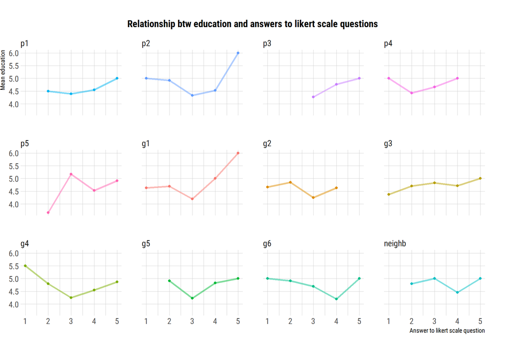

```r
survey_df_e <- survey_df_e %>%
  mutate(edu_num = unclass(survey_df_e$edu))

tidy_survey_df_e <- survey_df_e %>%
  select(edu_num, p1:g6, neighb) %>%
  data.matrix() %>%
  as_data_frame() %>%
  gather(key, value, -edu_num)

tidy_survey_df_e %>%
  group_by(key, value) %>%
  summarize(edu_num = mean(edu_num, na.rm = TRUE)) %>%
  ggplot(aes(value, edu_num, color = key)) +
  geom_line(size = 1.2, show.legend = FALSE, alpha = 0.5) +
  geom_point() +
  labs(title = "Relationship btw education and answers to likert scale questions",
       x = "Answer to likert scale question", y = "Mean education") +
  facet_wrap(~factor(key, ordered = T,
                     levels = c("p1", "p2", "p3", "p4", "p5", "g1", "g2",
                                "g3", "g4", "g5", "g6", "neighb")), nrow = 3) +
  theme_ipsum_rc() +
  theme(plot.title = element_text(size = 14, hjust = 0.5)) +
  theme(axis.text.y = element_text(hjust = 0)) +
  theme(legend.position = "none") +
  theme(plot.margin = unit(c(1,1,1,0), "cm")) +
  theme(
    panel.grid.minor.y = element_blank()
  )
```

For this plot, the education is coded as an integer value as shown in the following table (see the column `edu_num`). This table also shows the count for each level (under the column `n`).

```r
options(scipen = 999, digits = 3)

survey_df_e %>%
  count(edu, edu_num) %>%
  kable() %>%
  kable_styling(bootstrap_options = c("striped", "hover"),
                full_width = F, position = "left", font_size = 14)
```

| edu | edu_num | n |
| --- | --- | --- |
| Primary_or_None | 1 | 1 |
| High_school | 2 | 2 |
| Bachelor | 4 | 5 |
| Master | 5 | 29 |
| PhD | 6 | 2 |

Here below is a reminder of the questions and their variable names.

```r
meta <- data_frame(question = header_lookup$google_f_header[c(5:15, 29)],
                   variable_name = names(survey_df_e)[c(5:16)])

meta %>%
  kable() %>%
  kable_styling(bootstrap_options = c("striped", "hover"),
                full_width = T, font_size = 14)
```

| question | variable_name |
| --- | --- |
| Face-to-face interactions are necessary for collective action. | p1 |
| For most citizens on a civic crowdfunding platform, personnally funding a citizen’s initiative is enough to satisfy their desire to engage in this project. | p2 |
| Citizens would like to participate in debates on local public issues that they care about. | p3 |
| It is relatively easy for citizens to find places where local public issues are collectively debated. | p4 |
| I would welcome the possibility for citizens on a crowdfunding platform to express their disagreement about some aspects of the projects they contribute to financially. | p5 |
| Civic crowdfunding represents a direct threat to the funding of public goods and services by the local government. | g1 |
| I regard crowdfunded citizen’s initiatives as a sort of *Do-It-Yourself government*. | g2 |
| The local government is able to identify the projects that are most wanted by citizens. | g3 |
| Civic crowdfunding platforms could play a role of intermediary between citizen’s initiatives and the local government. | g4 |
| General interest issues are addressed more efficiently by crowdfunded citizen’s initiatives than by the local government. | g5 |
| General interest issues are addressed more efficiently by crowdfunded citizen’s initiatives than by non-profit organizations subsidized by the local government. | g6 |
| My interest in contributing to the future of my neighborhood has increased in the past several years. | neighb |

We can observe from this plot that there is a possible positive relationship between education and the extent to which respondents agreed with the statement: **The local government is able to identify the projects that are most wanted by citizens**, although this should be confirmed by the statistical modeling that we will perform in the next chapter.

### Distribution of answers for independent variables broken down by age

Here below is a plot showing the mean age versus answers to the independent variables questions, broken down by the independent variables questions.

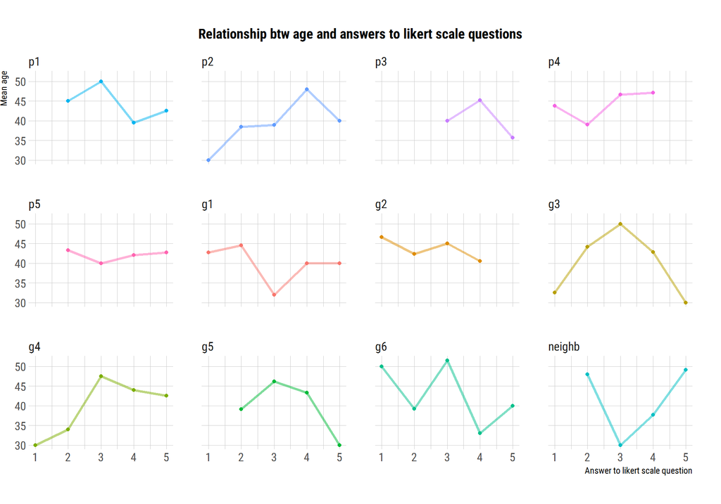

```r
survey_df_e <- survey_df_e %>%
  mutate(age_num = ifelse(age == "14_and_below", 12,
                          ifelse(age == "14_17", 16,
                                 ifelse(age == "18_24", 20,
                                        ifelse(age == "25_34", 30,
                                               ifelse(age == "35_44", 40,
                                                      ifelse(age == "45_54", 50,
                                                             ifelse(age == "55_64", 60,
                                                                    ifelse(age == "65_74", 70, 80)))))))))

tidy_survey_df_e <- survey_df_e %>%
  select(age_num, p1:g6, neighb) %>%
  data.matrix() %>%
  as_data_frame() %>%
  gather(key, value, -age_num)

tidy_survey_df_e %>%
  group_by(key, value) %>%
  summarize(age_num = mean(age_num, na.rm = TRUE)) %>%
  ggplot(aes(value, age_num, color = key)) +
  geom_line(size = 1.2, show.legend = FALSE, alpha = 0.5) +
  geom_point() +
  labs(title = "Relationship btw age and answers to likert scale questions",
       x = "Answer to likert scale question", y = "Mean age") +
  facet_wrap(~factor(key, ordered = T,
                     levels = c("p1", "p2", "p3", "p4", "p5", "g1", "g2",
                                "g3", "g4", "g5", "g6", "neighb")), nrow = 3) +
  theme_ipsum_rc() +
  theme(plot.title = element_text(size = 14, hjust = 0.5)) +
  theme(axis.text.y = element_text(hjust = 0)) +
  theme(legend.position = "none") +
  theme(plot.margin = unit(c(1,1,1,0), "cm")) +
  theme(
    panel.grid.minor.y = element_blank()
  )
```

For this plot, the age group is coded as an integer value as shown in the following table (see the column `age_num`). This table also shows the count for each level (under the column `n`).

```r
options(scipen = 999, digits = 3)

survey_df_e %>%
  count(age, age_num) %>%
  kable() %>%
  kable_styling(bootstrap_options = c("striped", "hover"),
                full_width = F, position = "left", font_size = 14)
```

| age | age_num | n |
| --- | --- | --- |
| 18_24 | 20 | 3 |
| 25_34 | 30 | 14 |
| 35_44 | 40 | 6 |
| 45_54 | 50 | 7 |
| 55_64 | 60 | 7 |
| 65_74 | 70 | 1 |
| 75_plus | 80 | 1 |

From this plot we cannot spot any clear trend.

# Logistic Regression modeling

### Introduction

Similar to what we did in Part I for the citizens, we are going to fit a series of multiple binary logistic regression models in order to see which predictors (in our case the independent variables) are associated with the likelihood of entrepreneurs to be interested in joining a civic crowdfunding platforms.

Here again, our dependent variable has more than two classes (three in this case: `Not_interested`, `Could_be_interested` and `Is_Ready`). Therefore, we will fit several models after having split our dependent variable classes into two groups, in several ways.

### Logistic regression with Interest as the target variable

#### Model 1

In this section and also in the next one, we will fit a model with Interest (in joining a civic crowdfunding platform) as the target variable and all of the independent variables, as well as the control variables, as the explanatory variables.

For the first model, we will split the Interest variable into the two following groups:

- Class 0: `Not_interested`;
- Class 1: The rest of the possible classes combined (`Could_be_interested` and `Is_Ready`).

Also, we filter out observations with gender other than `Female` and `Male`. Then, `Females` are represented by the integer value 1 and `Males` are represented by the integer value 2.

Answers to Likert scale questions range from 1 (`Strongly_disagree`) to 5 (`Strongly_agree`).

Answers to Likert scale questions range from 1 (`Strongly_disagree`) to 5 (`Strongly agree`).

Answers to the question about the age of the respondent range from 1 (`Under_14`) to 9 (`75_plus`).

Answers to the education question range from 1 (`Primary_or_None`) to 6 (`PhD`).

Finally, answers to the location and language questions have three levels:

- `Brussels` = 1, `Flanders` = 2, `Wallonia` = 3;
- `English` = 1, `Dutch` = 2, `French` = 3.

Thus, the first few rows of the input to the model look like this:

```r
survey_df_e_mat <- survey_df_e %>%
  filter(gender %in% c("Female", "Male")) %>%
  mutate(interest_binary = ifelse(interest == "Not_interested", 0, 1)) %>%
  select(interest_binary, language, p1:edu) %>%
  data.matrix() %>%
  as_data_frame()

survey_df_e_mat %>%
  head() %>%
  kable() %>%
  kable_styling(bootstrap_options = c("striped", "hover"),
                full_width = T, font_size = 14)
```

| interest_binary | language | p1 | p2 | p3 | p4 | p5 | g1 | g2 | g3 | g4 | g5 | g6 | neighb | loc | gender | age | edu |
| --- | --- | --- | --- | --- | --- | --- | --- | --- | --- | --- | --- | --- | --- | --- | --- | --- | --- |
| 1 | 3 | 5 | 3 | 5 | 1 | 3 | 4 | 3 | 1 | 3 | 3 | 1 | 5 | 1 | 2 | 6 | 5 |
| 1 | 3 | 4 | 4 | 4 | 2 | 2 | 2 | 4 | 2 | 4 | 3 | 4 | 4 | 1 | 2 | 5 | 1 |
| 1 | 3 | 4 | 3 | 5 | 2 | 5 | 2 | 2 | 1 | 2 | 3 | 2 | 4 | 2 | 2 | 5 | 4 |
| 1 | 1 | 5 | 5 | 5 | 2 | 3 | 5 | 4 | 4 | 4 | 4 | 4 | 4 | 1 | 1 | 5 | 6 |
| 1 | 3 | 4 | 4 | 3 | 4 | 2 | 2 | 2 | 4 | 3 | 2 | 2 | 5 | 3 | 2 | 7 | 5 |
| 1 | 3 | 3 | 4 | 3 | 2 | 4 | 3 | 4 | 4 | 4 | 4 | 4 | 4 | 1 | 1 | 4 | 2 |

Let us now examine the output of the model:

```r
glm_e_1 <- glm(interest_binary ~ .,  family = "binomial",
                  data = survey_df_e_mat)

summary(glm_e_1)
```

```
##
## Call:
## glm(formula = interest_binary ~ ., family = "binomial", data = survey_df_e_mat)
##
## Deviance Residuals:
##          Min            1Q        Median            3Q           Max
## -0.000008053   0.000000021   0.000000021   0.000002826   0.000007360
##
## Coefficients:
##                Estimate  Std. Error z value Pr(>|z|)
## (Intercept)      43.232 3077549.046       0        1
## language          5.733  358960.435       0        1
## p1                3.129  187509.506       0        1
## p2                4.139  212730.988       0        1
## p3               -7.843  143647.712       0        1
## p4               -2.787  119859.452       0        1
## p5               -1.936  237211.576       0        1
## g1                3.348  328149.285       0        1
## g2               -1.828  173352.396       0        1
## g3               -1.600  189327.074       0        1
## g4                7.895  238950.246       0        1
## g5               -0.410  181919.554       0        1
## g6               -9.881  142554.362       0        1
## neighb           -3.069  317087.240       0        1
## loc               0.296  458929.396       0        1
## gender            3.281  834734.769       0        1
## age              -1.442  279644.120       0        1
## edu               2.479   82403.834       0        1
##
## (Dispersion parameter for binomial family taken to be 1)
##
##     Null deviance: 9.24862260353271  on 37  degrees of freedom
## Residual deviance: 0.00000000037884  on 20  degrees of freedom
## AIC: 36
##
## Number of Fisher Scoring iterations: 25
```

Therefore, we cannot infer anything regarding factors that are associated with the likelihood of entrepreneurs not to be interested in joining a civic crowdfunding platform as opposed to being somewhat interested (`Could_be_interested`) or definetly interested (`Is_Ready`).

#### Model 2

In this second model, we are filtering out the observations where entrepeneurs are not interested in joining a civic crowdfunding platform, therefore we are now focusing on a subset of the data. Then we split the observations into the two following groups, related to the `interest` variable:

- Class 0: `Could_be_interested`;
- Class 1: `Is_Ready`.

The rest of the model is similar to the model 1.

```r
survey_df_e_mat <- survey_df_e %>%
  filter(gender %in% c("Female", "Male")) %>%
  filter(interest != "Not_interested") %>%
  mutate(interest_binary = ifelse(interest == "Is_ready", 1, 0)) %>%
  select(interest_binary, language, p1:edu) %>%
  data.matrix() %>%
  as_data_frame()

glm_e_2 <- glm(interest_binary ~ .,  family = "binomial",
                  data = survey_df_e_mat)

summary(glm_e_2)
```

```
##
## Call:
## glm(formula = interest_binary ~ ., family = "binomial", data = survey_df_e_mat)
##
## Deviance Residuals:
##          Min            1Q        Median            3Q           Max
## -0.000018263  -0.000003896  -0.000000021  -0.000000021   0.000017733
##
## Coefficients:
##               Estimate Std. Error z value Pr(>|z|)
## (Intercept)    -274.70 2119914.75       0        1
## language        -50.46  359104.27       0        1
## p1               27.77  262051.60       0        1
## p2              -34.72  184517.74       0        1
## p3                1.86  295410.54       0        1
## p4               40.90  202430.88       0        1
## p5               20.45  122281.08       0        1
## g1               30.20  122849.81       0        1
## g2              -23.19  250528.64       0        1
## g3               -4.76  186271.93       0        1
## g4               24.36  128692.86       0        1
## g5               -9.68  109096.52       0        1
## g6               -4.43  141918.69       0        1
## neighb           20.86  248870.19       0        1
## loc              16.70  489558.79       0        1
## gender           80.43  136489.25       0        1
## age             -25.97   61604.18       0        1
## edu               8.59  332359.40       0        1
##
## (Dispersion parameter for binomial family taken to be 1)
##
##     Null deviance: 35.8933405491689  on 36  degrees of freedom
## Residual deviance:  0.0000000017871  on 19  degrees of freedom
## AIC: 36
##
## Number of Fisher Scoring iterations: 25
```

Again, the model did not converge. This is maybe due to the fact that the sample size for the entrepreneurs is too small overall to be able to build a logistic regression model.

# Conclusions

It is now time to draw conclusions from this study.

First, we should mention that it is not possible to generalize those conclusions to the population of interest, since the respondents were not sampled at random. Furthermore, the sample is biased, as evidenced by the over-representation of respondents with a masters degree.

Let us remind ourselves the hypotheses that we hoped to confirm with this study.

- Hypotheses related to the entrepreneurs:
  - H1: A more participative platform is positively correlated with the interest to join a civic crowdfunding platform.
  - H2: A positive opinion on projects that are co-created by social entrepreneurs and the local government is positively correlated with the interest to join a civic crowdfunding platform.
- Hypotheses related to the citizens:
  - H3: The wish for more participation in debates on public issues is positively correlated with the interest to support citizens initiatives.
  - H4: A positive opinion on projects that are co-created by social entrepreneurs and the local government through civic crowdfunding platforms is positively correlated with the interest to support citizens initiatives.

Based on the observations we have made throughout this document, we can conclude the following:

1. For the entrepreneurs (active members of a local citizens initiative, social project or social organization):
   1. Unfortunately, the ‘response rate’ for the entrepreneurs was not sufficient for us to be able to fit a statistical model, thus we can only rely on summary statistics and visualizations to draw conclusions here.
   2. We observed that most entrepreneurs recognize in general the need for face-to-face interactions, most of them think that citizens would like to participate in debates on local public issues, and they would welcome the possibility for citizens on a crowdfunding platform to express their disagreement about some aspects of the projects they contribute to financially.
   3. However, we cannot use those results to validate H1 since they could not be compared with the entrepreneurs’ interest to join a civic crowdfunding platform.
   4. We also observed that entrepreneurs generally back the idea of civic crowdfunding platform playing a role of intermediary between citizens initiatives and the local authorities. This is an interesting insight, although once again this could not be correlated with the entrepreneurs’ interest to join a civic crowdfunding platform, therefore it is not possible to validate H2.
2. For the citizens:
   1. We observed that most respondents think that it is difficult for citizens to find places where local public issues are collectively debated. Moreover, they seem to have a positive opinion about civic crowdfunding platforms, since there seems to be a consensus about the fact that the latter don’t represent a threat to funding of services by the government.
   2. They generally agree with the entrepreneurs about the role of intermediary between citizens initiatives and the local authorities that civic crowdfunding platforms could play.
   3. Respondents who want to participate in debates on local public issues are more likely to be willing to fund or volunteer in a citizens initiative.
   4. It is those who reported to be only potentially interested to fund or volunteer in a citizen initiative (as opposed to those who reported to be ready to fund or volunteer) that reported the most enthusiasm regarding the role of intermediary between citizen initiatives and local authorities that civic crowdfunding platforms could play. Perhaps would they be ready to fund or volunteer once this role is fulfilled?
   5. Similarly, respondents only potentially interested to fund or volunteer, in particular those willing to volunteer, were more likely to report that they would be more inclined to contribute financially if they had the possibility to express their disagreement on the projects they would support. Although, once again, we cannot draw causal inferences in this study, that makes a lot of sense.
   6. Respondents who agree that personally funding a citizens initiative is enough to satisfy their desire to engage in this project were more likely to be willing to fund rather than to volunteer. That is not such a surprising result after all.
   7. Respondents who reported that they would like to participate in debates on local public issues are more likely to be already investing in citizens initiatives than not investing at all. This is quite an interesting insight, which backs our hypothesis H3.

So, overall, although we are not claiming here that all of our hypotheses are verified, there are multiple indications that a civic crowdfunding platform such as BrusselsTogether would be more attractive to both citizens and entrepreneurs should it strive for being a truly participative platform as well as a communication channel, an intermediary between the initiatives and the local authorities.